# STA465 - Assignment #5

Owen Haworth

02/04/2021

```r
# R packages:
library(sf)
library(INLA)
library(SpatialEpi)
library(tidyverse)
library(spdep)
library(tmap)
library(geoR)
library(sp)
library(rgdal)
library(raster)
library(geodist)
library(tibble)
```

# Question 1: Sloths in Costa Rica

## Question 1.1

```r
load("~/Hwk5Data.RData")

grid
```

```
## class       : SpatialPolygonsDataFrame
## features    : 511
## extent      : -85.90801, -82.60801, 8.089453, 11.18945  (xmin, xmax, ymin, ymax)
## crs         : +proj=longlat +datum=WGS84 +no_defs +ellps=WGS84 +towgs84=0,0,0
## variables   : 6
## names       : layer,   id,  Y, cellarea,    cov,  id2
## min values  :     0,    3,  0,     0.01,     78,    3
## max values  :    96, 1021, 96,     0.01, 223.25, 1021
```

```r
st_crs(grid)
```

```
## Coordinate Reference System:
##   User input: +proj=longlat +datum=WGS84 +no_defs +ellps=WGS84 +towgs84=0,0,0
##   wkt:
## BOUNDCRS[
##     SOURCECRS[
##         GEOGCRS["unknown",
##             DATUM["World Geodetic System 1984",
##                 ELLIPSOID["WGS 84",6378137,298.257223563,
##                     LENGTHUNIT["metre",1]],
##                 ID["EPSG",6326]],
##             PRIMEM["Greenwich",0,
##                 ANGLEUNIT["degree",0.0174532925199433],
##                 ID["EPSG",8901]],
##             CS[ellipsoidal,2],
##                 AXIS["longitude",east,
##                     ORDER[1],
##                     ANGLEUNIT["degree",0.0174532925199433,
##                         ID["EPSG",9122]]],
##                 AXIS["latitude",north,
##                     ORDER[2],
##                     ANGLEUNIT["degree",0.0174532925199433,
##                         ID["EPSG",9122]]]]],
##     TARGETCRS[
##         GEOGCRS["WGS 84",
##             DATUM["World Geodetic System 1984",
##                 ELLIPSOID["WGS 84",6378137,298.257223563,
##                     LENGTHUNIT["metre",1]]],
##             PRIMEM["Greenwich",0,
##                 ANGLEUNIT["degree",0.0174532925199433]],
##             CS[ellipsoidal,2],
##                 AXIS["latitude",north,
##                     ORDER[1],
##                     ANGLEUNIT["degree",0.0174532925199433]],
##                 AXIS["longitude",east,
##                     ORDER[2],
##                     ANGLEUNIT["degree",0.0174532925199433]],
##             ID["EPSG",4326]]],
##     ABRIDGEDTRANSFORMATION["Transformation from unknown to WGS84",
##         METHOD["Geocentric translations (geog2D domain)",
##             ID["EPSG",9603]],
##         PARAMETER["X-axis translation",0,
##             ID["EPSG",8605]],
##         PARAMETER["Y-axis translation",0,
##             ID["EPSG",8606]],
##         PARAMETER["Z-axis translation",0,
##             ID["EPSG",8607]]]]
```

The class of the grid data set is a spatial polygons data frame (spatial polygons class).

The coordinate reference system (CRS) of the grid data set (grid) is “+proj=longlat +datum=WGS84 +no_defs +ellps=WGS84 +towgs84=0,0,0”. The CRS is a geographic (geographic coordinate system) with units in degrees for both longitude and latitude. Also, the CRS has a World Geodetic System 1984 (“WGS 84”) datum, a World Geodetic System 1984 (“WGS 84”) ellipsoid, and a “+towgs84=0,0,0” conversion factor.

## Question 1.2

#### Model #1: Setting Weakly Informative Priors for the ‘iid’ and ‘rw2d’ Components

```r
ncol <- ncol(r)

formula.grid1 <- Y ~ 1 + cov +
  f(id, model = "rw2d", nrow = nrow, ncol = ncol, hyper = list(prec = list(prior = "loggamma", param = c(1, 1/1000)))) +
  f(id2, model = "iid", hyper = list(prec = list(prior = "loggamma", param = c(1, 1/1000))))

res.grid1 <- inla(formula.grid1, family = "poisson", data = grid@data, E = cellarea,
                  control.predictor = list(compute = TRUE))

summary(res.grid1)
```

```
##
## Call:
##    c("inla(formula = formula.grid1, family = \"poisson\", data =
##    grid@data, ", " E = cellarea, control.predictor = list(compute =
##    TRUE))" )
## Time used:
##     Pre = 0.622, Running = 25.9, Post = 0.9, Total = 27.4
## Fixed effects:
##               mean    sd 0.025quant 0.5quant 0.975quant   mode kld
## (Intercept) -2.443 1.469     -5.525    -2.37      0.234 -2.221   0
## cov          0.020 0.007      0.007     0.02      0.034  0.019   0
##
## Random effects:
##   Name     Model
##     id Random walk 2D
##    id2 IID model
##
## Model hyperparameters:
##                    mean    sd 0.025quant 0.5quant 0.975quant  mode
## Precision for id  0.431 0.271      0.133    0.360      1.140 0.263
## Precision for id2 0.240 0.045      0.164    0.235      0.341 0.227
##
## Expected number of effective parameters(stdev): 228.98(13.38)
## Number of equivalent replicates : 2.23
##
## Marginal log-Likelihood:  -1648.86
## Posterior marginals for the linear predictor and
##  the fitted values are computed
```

```r
# Mean and 95% Credible Intervals of the Estimated Parameters for the Model Table:
res.grid1.ci.table <- matrix(c(-2.443, -5.525, 0.234, 0.020, 0.007, 0.034,
                               0.431, 0.133, 1.140, 0.240, 0.164, 0.341),
                             nrow = 4, ncol = 3, byrow = TRUE)

colnames(res.grid1.ci.table) <- c("Mean", "Lower Bound", "Upper Bound")
rownames(res.grid1.ci.table) <- c("Beta 0", "Beta 1", "id", "id2")
names(dimnames(res.grid1.ci.table)) <-
  list("", "Mean & 95% Credible Intervals for Model #1")

res.grid1.ci.table <- as.table(res.grid1.ci.table)
res.grid1.ci.table
```

```
##         Mean & 95% Credible Intervals for Model #1
##            Mean Lower Bound Upper Bound
##   Beta 0 -2.443      -5.525       0.234
##   Beta 1  0.020       0.007       0.034
##   id      0.431       0.133       1.140
##   id2     0.240       0.164       0.341
```

#### Model #2: Setting Noninformative Priors for the ‘iid’ and ‘rw2d’ Components

```r
formula.grid2 <- Y ~ 1 + cov +
  f(id, model = "rw2d", nrow = nrow, ncol = ncol, hyper = list(prec = list(prior = "loggamma", param = c(1000, 1/1000)))) +
  f(id2, model = "iid", hyper = list(prec = list(prior = "loggamma", param = c(1000, 1/1000))))

res.grid2 <- inla(formula.grid2, family = "poisson", data = grid@data, E = cellarea, control.predictor = list(compute = TRUE))

summary(res.grid2)
```

```
##
## Call:
##    c("inla(formula = formula.grid2, family = \"poisson\", data =
##    grid@data, ", " E = cellarea, control.predictor = list(compute =
##    TRUE))" )
## Time used:
##     Pre = 0.513, Running = 7.22, Post = 0.94, Total = 8.67
## Fixed effects:
##               mean    sd 0.025quant 0.5quant 0.975quant   mode kld
## (Intercept) -0.479 0.465     -1.419   -0.469      0.407 -0.450   0
## cov          0.028 0.002      0.023    0.028      0.032  0.028   0
##
## Random effects:
##   Name     Model
##     id Random walk 2D
##    id2 IID model
##
## Model hyperparameters:
##                    mean       sd 0.025quant  0.5quant 0.975quant      mode
## Precision for id  1e+06 31621.70  938638.54 999315.47 1063114.06 998692.82
## Precision for id2 1e+06 31622.15  939012.59 999584.26 1063446.37 998962.63
##
## Expected number of effective parameters(stdev): 4.01(0.00)
## Number of equivalent replicates : 127.39
##
## Marginal log-Likelihood:  -3034.41
## Posterior marginals for the linear predictor and
##  the fitted values are computed
```

```r
summary(res.grid2)$hyperpar[1]
```

```
##                       mean
## Precision for id  999711.1
## Precision for id2 999979.9
```

```r
# Mean and 95% Credible Intervals of the Estimated Parameters for the Model Table:
res.grid2.ci.table <- matrix(c(-0.479, -1.419, 0.407, 0.028, 0.023, 0.032,
                               999711.1, 938638.54, 1063114.06,
                               999979.9, 939012.59, 1063446.37),
                             nrow = 4, ncol = 3, byrow = TRUE)

colnames(res.grid2.ci.table) <- c("Mean", "Lower Bound", "Upper Bound")
rownames(res.grid2.ci.table) <- c("Beta 0", "Beta 1", "id", "id2")
names(dimnames(res.grid2.ci.table)) <-
  list("", "Mean & 95% Credible Intervals for Model #2")

res.grid2.ci.table <- as.table(res.grid2.ci.table)
res.grid2.ci.table
```

```
##         Mean & 95% Credible Intervals for Model #2
##                 Mean Lower Bound Upper Bound
##   Beta 0      -0.479      -1.419       0.407
##   Beta 1       0.028       0.023       0.032
##   id      999711.100  938638.540 1063114.060
##   id2     999979.900  939012.590 1063446.370
```

There are large differences for the ‘iid’ and ‘rw2d’ components between model #1 and model #2. Model #2 has much larger mean estimates and 95% credible intervals for the ‘iid’ and ‘rw2d’ components compared to Model #1, which is because the noninformative priors for the ‘iid’ and ‘rw2d’ components are giantic assumptions, whereas the weakly informative priors are closer to the actual values of the parameters (not a gigantic assumption). In addition, when comparing the models, Model #2 has larger mean estimates for Beta 0 and Beta 1, but their corresponding 95% credible intervals are smaller.

## Question 1.3

#### Model #1: Setting Weakly Informative Priors for the ‘iid’ and ‘rw2d’ Components

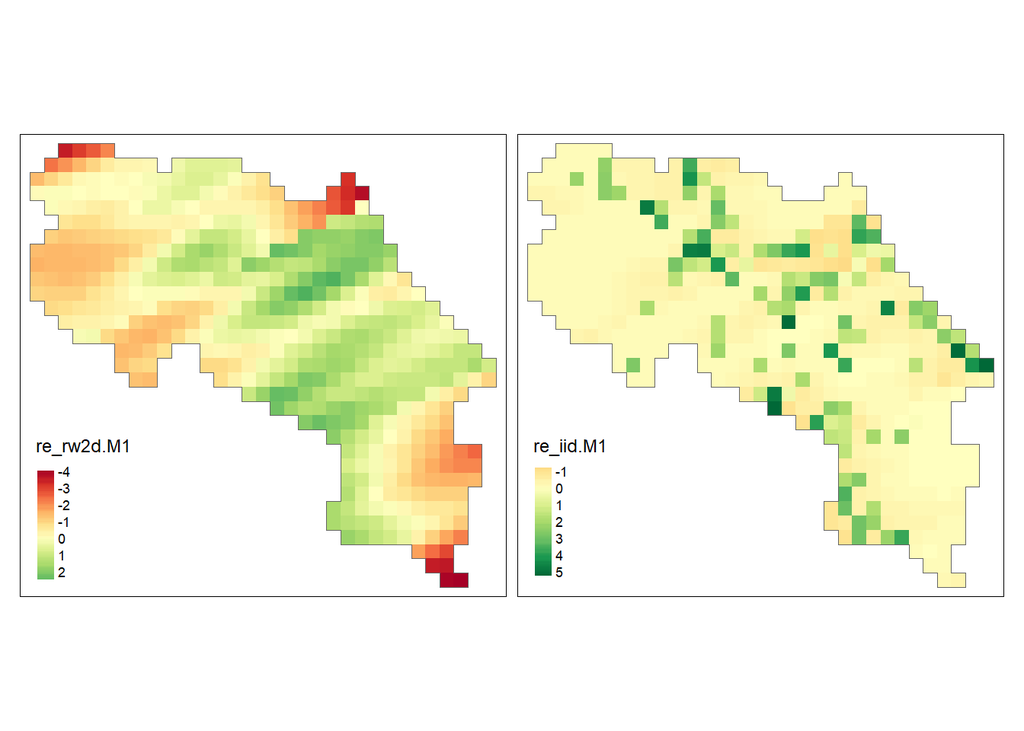

```r
# Maps of the random Effects (both rw2d and iid):
grid$re_rw2d.M1 <- res.grid1$summary.random$id[grid$id, "mean"]
grid$re_iid.M1 <- res.grid1$summary.random$id2[, "mean"]

tmap_mode("plot")
tm_shape(grid) +
  tm_polygons(col = c("re_rw2d.M1", "re_iid.M1"), style = "cont", border.col = "transparent") +
  tm_shape(gridborder) +
  tm_borders() +
  tm_facets(ncol = 2) +
  tm_legend(legend.position = c("left", "bottom"))
```

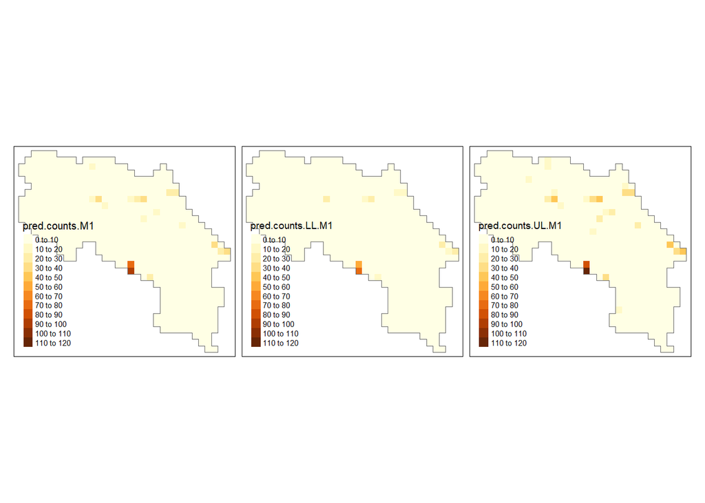

```r
# Maps of the Predicted Counts Per Cell, and the Lower and Upper Limits of the 95% Credible Interval:
cellarea <- resolution * resolution

grid$pred.counts.M1 <- res.grid1$summary.fitted.values[, "mean"] * cellarea
grid$pred.counts.LL.M1 <- res.grid1$summary.fitted.values[, "0.025quant"] * cellarea
grid$pred.counts.UL.M1 <- res.grid1$summary.fitted.values[, "0.975quant"] * cellarea

tmap_mode("plot")
tm_shape(grid) +
  tm_polygons(col = c("pred.counts.M1", "pred.counts.LL.M1", "pred.counts.UL.M1"),
              style = 'fixed', border.col = "transparent",
              breaks = seq(0, ceiling(max(grid$pred.counts.UL.M1)) + 4, 10)) +
  tm_shape(gridborder) +
  tm_borders() +
  tm_facets(ncol = 3) +
  tm_legend(legend.position = c("left", "bottom"))
```

#### Model #2: Setting Noninformative Priors for the ‘iid’ and ‘rw2d’ Components

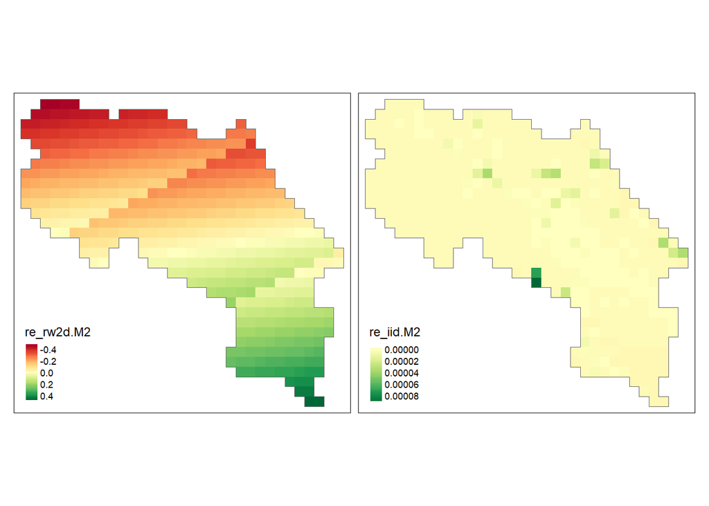

```r
# Maps of the random Effects (both rw2d and iid):
grid$re_rw2d.M2 <- res.grid2$summary.random$id[grid$id, "mean"]
grid$re_iid.M2 <- res.grid2$summary.random$id2[, "mean"]

tmap_mode("plot")
tm_shape(grid) +
  tm_polygons(col = c("re_rw2d.M2", "re_iid.M2"), style = "cont", border.col = "transparent") +
  tm_shape(gridborder) +
  tm_borders() +
  tm_facets(ncol = 2) +
  tm_legend(legend.position = c("left", "bottom"))
```

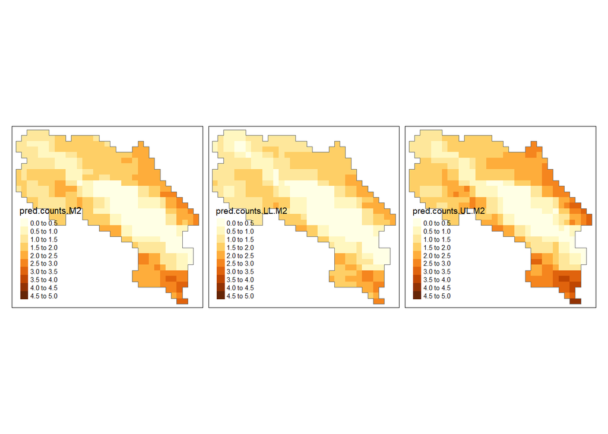

```r
# Maps of the Predicted Counts Per Cell, and the Lower and Upper Limits of the 95% Credible Interval:
cellarea <- resolution * resolution

grid$pred.counts.M2 <- res.grid2$summary.fitted.values[, "mean"] * cellarea
grid$pred.counts.LL.M2 <- res.grid2$summary.fitted.values[, "0.025quant"] * cellarea
grid$pred.counts.UL.M2 <- res.grid2$summary.fitted.values[, "0.975quant"] * cellarea

tmap_mode("plot")
tm_shape(grid) +
  tm_polygons(col = c("pred.counts.M2", "pred.counts.LL.M2", "pred.counts.UL.M2"),
              style = 'fixed', border.col = "transparent",
              breaks = seq(0, ceiling(max(grid$pred.counts.UL.M2)), 0.5)) +
  tm_shape(gridborder) +
  tm_borders() +
  tm_facets(ncol = 3) +
  tm_legend(legend.position = c("left", "bottom"))
```

# Question 2:

## Question 2.1

```r
# Getting data and setting it up
data(pennLC)
population <- pennLC$data$population
cases <- pennLC$data$cases
n.strata <- 16
E <- expected(population, cases, n.strata)
d <- aggregate(x = pennLC$data$cases, by = list(county = pennLC$data$county), FUN = sum)

# From spatial polygon to simple feature
pennLC.sf <- st_as_sf(pennLC$spatial.polygon)
pennLC.sf$county <- d$county
pennLC.sf$counts <- d$x
pennLC.sf$E <- E[match(pennLC.sf$county, unique(pennLC$data$county))]
pennLC.sf <- merge(pennLC.sf, pennLC$smoking, by.x = "county", by.y = "county")
pennLC.sf <- pennLC.sf%>%
  mutate(SIR = counts/E)

## Values of E_i and neighborhood structure
E.penn <- pennLC.sf$E
neighbor.penn <- poly2nb(pennLC.sf)

nb2INLA("npenn.adj", neighbor.penn)
g <- inla.read.graph(filename = "npenn.adj")

pennLC.sf$re_u <- 1:nrow(pennLC.sf)
pennLC.sf$re_v <- 1:nrow(pennLC.sf)
```

#### Model #1: Complete Pooling and Smoking Covariate (no random effects)

```r
formula.penn1 <- counts ~ smoking

res.penn1 <- inla(formula.penn1, family = "poisson", data = pennLC.sf, E = E.penn,
                  control.predictor = list(compute = TRUE),
                  control.compute = list(cpo = TRUE))

summary(res.penn1)
```

```
##
## Call:
##    c("inla(formula = formula.penn1, family = \"poisson\", data =
##    pennLC.sf, ", " E = E.penn, control.compute = list(cpo = TRUE),
##    control.predictor = list(compute = TRUE))" )
## Time used:
##     Pre = 0.324, Running = 0.201, Post = 0.2, Total = 0.726
## Fixed effects:
##               mean    sd 0.025quant 0.5quant 0.975quant   mode kld
## (Intercept) -0.373 0.088     -0.547   -0.373     -0.199 -0.372   0
## smoking      1.559 0.367      0.839    1.559      2.279  1.559   0
##
## Expected number of effective parameters(stdev): 2.06(0.00)
## Number of equivalent replicates : 32.58
##
## Marginal log-Likelihood:  -289.10
## CPO and PIT are computed
##
## Posterior marginals for the linear predictor and
##  the fitted values are computed
```

```r
# CPO Values:
res.penn1$cpo$cpo
```

```
##  [1] 1.132952e-02 4.743505e-04 2.350158e-03 2.103937e-02 3.942560e-02
##  [6] 2.206635e-02 1.528526e-02 4.722951e-02 1.554382e-03 1.375431e-02
## [11] 1.041966e-03 9.736544e-02 1.321160e-02 1.031908e-02 2.249318e-02
## [16] 6.847609e-02 4.633905e-02 3.039324e-02 3.244491e-02 3.652954e-02
## [21] 1.414177e-03 6.745987e-03 1.565598e-03 7.131924e-02 2.519124e-02
## [26] 1.570588e-02 1.639308e-01 3.585032e-02 1.179782e-01 4.228884e-02
## [31] 1.646447e-02 4.567204e-02 3.139418e-02 5.399109e-04 2.487443e-03
## [36] 1.811410e-03 3.463327e-03 3.369920e-03 2.436662e-02 2.376704e-03
## [41] 2.844071e-02 5.218027e-02 5.150621e-03 4.421174e-02 2.008978e-02
## [46] 1.457325e-03 1.621093e-02 1.241729e-02 3.967426e-02 6.864356e-02
## [51] 9.749380e-07 5.249658e-02 4.045889e-02 1.669359e-02 7.472152e-02
## [56] 1.606843e-03 3.256711e-02 6.546304e-02 1.967304e-02 7.217364e-02
## [61] 5.909685e-03 5.692231e-02 2.426662e-02 5.834819e-02 1.118382e-02
## [66] 2.118601e-02 2.065341e-02
```

```r
# PIT Values:
res.penn1$cpo$pit
```

```
##  [1] 0.0467755109 0.9938511056 0.0074474559 0.2181588210 0.1844267791
##  [6] 0.5748025315 0.9115040872 0.6930140273 0.9874578486 0.9081047645
## [11] 0.0046088617 0.8638443238 0.0490208982 0.0443273276 0.5719232362
## [16] 0.4576803710 0.5554734805 0.1083439419 0.8555592235 0.2756518555
## [21] 0.0067950114 0.0463661032 0.9869524730 0.5506758674 0.5603118133
## [26] 0.8953825329 0.3889606028 0.3724539998 0.5193348155 0.8482974343
## [31] 0.0503875827 0.4224570782 0.1281370449 0.0007759194 0.0149696570
## [36] 0.0139115799 0.0141246938 0.0137280188 0.4496995587 0.0181950846
## [41] 0.2254276462 0.2742627800 0.0252496581 0.8066834005 0.8826906135
## [46] 0.9835887570 0.0306431278 0.8935939389 0.3638689297 0.6519112064
## [51] 0.9999904123 0.2770606977 0.9136639429 0.1282341863 0.5799801803
## [56] 0.0051257165 0.0487554230 0.4329551997 0.0646008171 0.4405105485
## [61] 0.9830545417 0.3213343996 0.7268249744 0.6066565549 0.8698986495
## [66] 0.0513055709 0.3189822887
```

```r
# Map for predicted count of lung cancer cases across Pennsylvania:
pennLC.sf$Model1.Pred <- res.penn1$summary.fitted.values[,"mean"]*E.penn

tmap_mode("view")
tm_basemap("Stamen.Terrain") +
  tm_shape(pennLC.sf) +
  tm_fill(col = "Model1.Pred", title = "Predicted Lung Cancer Counts") +
  tm_tiles("Stamen.TerrainLabels") +
  tm_borders()
```

[interactive chart not shown]

```r
# Map for standard deviation (SD) of predicted counts of lung cancer cases across Pennsylvania:
pennLC.sf$Model1.SD <- res.penn1$summary.fitted.values[,"sd"]*E.penn

tmap_mode("view")
tm_basemap("Stamen.Terrain") +
  tm_shape(pennLC.sf) +
  tm_fill(col = "Model1.SD", title = "SD of Predicted Lung Cancer Counts") +
  tm_tiles("Stamen.TerrainLabels") +
  tm_borders()
```

[interactive chart not shown]

#### Model #2: Hierarchical Random Effect (iid) - (intercept only)

```r
formula.penn2 <- counts ~ f(re_v, model = "iid")

res.penn2 <- inla(formula.penn2, family = "poisson", data = pennLC.sf, E = E.penn,
                  control.predictor = list(compute = TRUE),
                  control.compute = list(cpo = TRUE))

summary(res.penn2)
```

```
##
## Call:
##    c("inla(formula = formula.penn2, family = \"poisson\", data =
##    pennLC.sf, ", " E = E.penn, control.compute = list(cpo = TRUE),
##    control.predictor = list(compute = TRUE))" )
## Time used:
##     Pre = 0.362, Running = 0.415, Post = 0.381, Total = 1.16
## Fixed effects:
##               mean    sd 0.025quant 0.5quant 0.975quant   mode kld
## (Intercept) -0.045 0.018     -0.082   -0.045     -0.011 -0.044   0
##
## Random effects:
##   Name     Model
##     re_v IID model
##
## Model hyperparameters:
##                      mean    sd 0.025quant 0.5quant 0.975quant   mode
## Precision for re_v 135.71 57.40      60.59   124.00     279.66 105.31
##
## Expected number of effective parameters(stdev): 27.44(4.89)
## Number of equivalent replicates : 2.44
##
## Marginal log-Likelihood:  -273.25
## CPO and PIT are computed
##
## Posterior marginals for the linear predictor and
##  the fitted values are computed
```

```r
# CPO Values:
res.penn2$cpo$cpo
```

```
##  [1] 0.0206117621 0.0013241411 0.0107473799 0.0182465518 0.0430804337
##  [6] 0.0097354659 0.0132094832 0.0281604168 0.0050718985 0.0049958440
## [11] 0.0095782022 0.0915896712 0.0205560085 0.0140650070 0.0123617938
## [16] 0.0618564504 0.0357097238 0.0510787876 0.0314751037 0.0354652561
## [21] 0.0046158247 0.0101167056 0.0043460647 0.0628956725 0.0093752552
## [26] 0.0124736600 0.1664594240 0.0280468624 0.1138533993 0.0357086205
## [31] 0.0242562695 0.0369481819 0.0373467477 0.0011452765 0.0144855539
## [36] 0.0053956811 0.0215055207 0.0070820813 0.0139757422 0.0116927642
## [41] 0.0294699095 0.0517297114 0.0233876998 0.0368021593 0.0159629018
## [46] 0.0062824167 0.0185002718 0.0098591440 0.0312218654 0.0621252805
## [51] 0.0002136871 0.0525471048 0.0257759382 0.0216967777 0.0672239373
## [56] 0.0090415362 0.0510576348 0.0594714158 0.0408289969 0.0648893700
## [61] 0.0024798311 0.0545171520 0.0147092008 0.0480682741 0.0062109840
## [66] 0.0394614004 0.0128543416
```

```r
# PIT Values:
res.penn2$cpo$pit
```

```
##  [1] 0.125676762 0.906176406 0.051121165 0.641617455 0.261593374 0.741233744
##  [7] 0.875796492 0.836365374 0.844715714 0.957218379 0.091378592 0.870677407
## [13] 0.101806526 0.083273313 0.550921364 0.510710730 0.605976001 0.258514007
## [19] 0.805388080 0.600495712 0.040265252 0.136147416 0.864740871 0.591765821
## [25] 0.842459692 0.860328327 0.411923152 0.508797088 0.563498343 0.854184290
## [31] 0.090708839 0.595779120 0.194379537 0.001735097 0.258398758 0.110069250
## [37] 0.177522608 0.043180025 0.551121234 0.358906841 0.548487117 0.345719438
## [43] 0.268069590 0.812317066 0.860866170 0.612772748 0.036795517 0.824326431
## [49] 0.387064901 0.622641585 0.987963877 0.357627040 0.948857820 0.381644617
## [55] 0.567222384 0.044532319 0.081064516 0.499883376 0.189542189 0.441693332
## [61] 0.991919506 0.390042018 0.732215973 0.652857807 0.839851981 0.115297698
## [67] 0.536501433
```

```r
# Map for predicted count of lung cancer cases across Pennsylvania:
pennLC.sf$Model2.Pred <- res.penn2$summary.fitted.values[,"mean"]*E.penn

tmap_mode("view")
tm_basemap("Stamen.Terrain") +
  tm_shape(pennLC.sf) +
  tm_fill(col = "Model2.Pred", title = "Predicted Lung Cancer Counts") +
  tm_tiles("Stamen.TerrainLabels") +
  tm_borders()
```

[interactive chart not shown]

```r
# Map for standard deviation (SD) of predicted counts of lung cancer cases across Pennsylvania:
pennLC.sf$Model2.SD <- res.penn2$summary.fitted.values[,"sd"]*E.penn

tmap_mode("view")
tm_basemap("Stamen.Terrain") +
  tm_shape(pennLC.sf) +
  tm_fill(col = "Model2.SD", title = "SD of Predicted Lung Cancer Counts") +
  tm_tiles("Stamen.TerrainLabels") +
  tm_borders()
```

[interactive chart not shown]

#### Model #3: Hierarchical Random Effect (iid) + Smoking Covariate

```r
formula.penn3 <- counts ~ smoking + f(re_v, model = "iid")

res.penn3 <- inla(formula.penn3, family = "poisson", data = pennLC.sf, E = E.penn,
                  control.predictor = list(compute = TRUE),
                  control.compute = list(cpo = TRUE))

summary(res.penn3)
```

```
##
## Call:
##    c("inla(formula = formula.penn3, family = \"poisson\", data =
##    pennLC.sf, ", " E = E.penn, control.compute = list(cpo = TRUE),
##    control.predictor = list(compute = TRUE))" )
## Time used:
##     Pre = 0.372, Running = 0.416, Post = 0.287, Total = 1.08
## Fixed effects:
##               mean    sd 0.025quant 0.5quant 0.975quant   mode kld
## (Intercept) -0.319 0.163     -0.642   -0.318      0.000 -0.317   0
## smoking      1.158 0.680     -0.186    1.158      2.498  1.158   0
##
## Random effects:
##   Name     Model
##     re_v IID model
##
## Model hyperparameters:
##                      mean    sd 0.025quant 0.5quant 0.975quant   mode
## Precision for re_v 150.90 70.55      63.95   135.33     330.68 112.25
##
## Expected number of effective parameters(stdev): 26.77(5.08)
## Number of equivalent replicates : 2.50
##
## Marginal log-Likelihood:  -275.61
## CPO and PIT are computed
##
## Posterior marginals for the linear predictor and
##  the fitted values are computed
```

```r
# CPO Values:
res.penn3$cpo$cpo
```

```
##  [1] 0.0209775157 0.0014768390 0.0086839340 0.0191422458 0.0450363498
##  [6] 0.0107115470 0.0118963630 0.0337114693 0.0032560309 0.0081708116
## [11] 0.0076050365 0.0893422358 0.0224175660 0.0181093342 0.0118459043
## [16] 0.0625768268 0.0355440359 0.0428877602 0.0263339582 0.0355054792
## [21] 0.0069152637 0.0130537693 0.0031013822 0.0628719117 0.0126986230
## [26] 0.0115448283 0.1687366210 0.0286140202 0.1142936242 0.0343170922
## [31] 0.0258205277 0.0379065057 0.0395554739 0.0012294358 0.0112804608
## [36] 0.0075480842 0.0132149297 0.0097611588 0.0140742011 0.0099038148
## [41] 0.0288755348 0.0536042333 0.0160016408 0.0352026107 0.0149017859
## [46] 0.0035059049 0.0221761479 0.0087633309 0.0332085325 0.0593446237
## [51] 0.0004931508 0.0539524319 0.0315259435 0.0209936975 0.0662861632
## [56] 0.0071583886 0.0432869044 0.0602259736 0.0323705496 0.0670514407
## [61] 0.0043685536 0.0561389631 0.0142860314 0.0478372714 0.0064575444
## [66] 0.0328184995 0.0132329853
```

```r
# PIT Values:
res.penn3$cpo$pit
```

```
##  [1] 0.126591487 0.896793510 0.039289184 0.489249880 0.277935235 0.702014014
##  [7] 0.896650814 0.775044047 0.918368788 0.918801328 0.066916659 0.877124365
## [13] 0.112488442 0.114273766 0.651798453 0.533856006 0.637279645 0.197207508
## [19] 0.857985784 0.466259652 0.065178005 0.194502024 0.917888413 0.614399996
## [25] 0.730851470 0.879915149 0.421428605 0.519009022 0.567799749 0.865647189
## [31] 0.097248444 0.556735998 0.209097620 0.001864387 0.169784223 0.174490134
## [37] 0.092155240 0.063012704 0.598819063 0.247661014 0.432157675 0.366899693
## [43] 0.149602543 0.830015911 0.878459307 0.857538335 0.044990714 0.859637204
## [49] 0.472004173 0.686997390 0.968331580 0.372138548 0.932153103 0.334732174
## [55] 0.625339372 0.033468459 0.067477787 0.516324003 0.137328353 0.500825580
## [61] 0.984110988 0.412386006 0.760201023 0.671086433 0.838537587 0.091660351
## [67] 0.541076260
```

```r
# Map for predicted count of lung cancer cases across Pennsylvania:
pennLC.sf$Model3.Pred <- res.penn3$summary.fitted.values[,"mean"]*E.penn

tmap_mode("view")
tm_basemap("Stamen.Terrain") +
  tm_shape(pennLC.sf) +
  tm_fill(col = "Model3.Pred", title = "Predicted Lung Cancer Counts") +
  tm_tiles("Stamen.TerrainLabels") +
  tm_borders()
```

[interactive chart not shown]

```r
# Map for standard deviation (SD) of predicted counts of lung cancer cases across Pennsylvania:
pennLC.sf$Model3.SD <- res.penn3$summary.fitted.values[,"sd"]*E.penn

tmap_mode("view")
tm_basemap("Stamen.Terrain") +
  tm_shape(pennLC.sf) +
  tm_fill(col = "Model3.SD", title = "SD of Predicted Lung Cancer Counts") +
  tm_tiles("Stamen.TerrainLabels") +
  tm_borders()
```

[interactive chart not shown]

#### Model #4: Spatial + iid Random Effect

```r
formula.penn4 <- counts ~ f(re_u, model = "besag", graph = g) + f(re_v, model = "iid")

res.penn4 <- inla(formula.penn4, family = "poisson", data = pennLC.sf, E = E.penn,
                  control.predictor = list(compute = TRUE),
                  control.compute = list(cpo = TRUE))

summary(res.penn4)
```

```
##
## Call:
##    c("inla(formula = formula.penn4, family = \"poisson\", data =
##    pennLC.sf, ", " E = E.penn, control.compute = list(cpo = TRUE),
##    control.predictor = list(compute = TRUE))" )
## Time used:
##     Pre = 0.43, Running = 1.4, Post = 0.37, Total = 2.2
## Fixed effects:
##               mean    sd 0.025quant 0.5quant 0.975quant   mode kld
## (Intercept) -0.048 0.015     -0.077   -0.048      -0.02 -0.048   0
##
## Random effects:
##   Name     Model
##     re_u Besags ICAR model
##    re_v IID model
##
## Model hyperparameters:
##                        mean       sd 0.025quant 0.5quant 0.975quant    mode
## Precision for re_u    77.38    37.86      28.18    69.42     172.67   56.06
## Precision for re_v 17779.27 17878.85    1108.96 12433.51   65491.05 2969.32
##
## Expected number of effective parameters(stdev): 19.55(4.38)
## Number of equivalent replicates : 3.43
##
## Marginal log-Likelihood:  -318.38
## CPO and PIT are computed
##
## Posterior marginals for the linear predictor and
##  the fitted values are computed
```

```r
# CPO Values:
res.penn4$cpo$cpo
```

```
##  [1] 0.0321349383 0.0020911529 0.0042428076 0.0217928552 0.0512552255
##  [6] 0.0082955506 0.0056214543 0.0207417997 0.0099249644 0.0053437337
## [11] 0.0081084046 0.0901379247 0.0171663087 0.0160352486 0.0151392628
## [16] 0.0633494795 0.0391652510 0.0563290156 0.0237959750 0.0384514660
## [21] 0.0086765682 0.0186229595 0.0085503350 0.0667401034 0.0108476621
## [26] 0.0169684269 0.1630096456 0.0251628955 0.1136641504 0.0464737896
## [31] 0.0309672054 0.0408668848 0.0343623037 0.0014913561 0.0163703573
## [36] 0.0071670755 0.0128932100 0.0097300511 0.0181456670 0.0162361632
## [41] 0.0325537530 0.0511845832 0.0155770423 0.0251150801 0.0127557590
## [46] 0.0076898971 0.0212442554 0.0123632071 0.0390868990 0.0562878718
## [51] 0.0006813226 0.0494713719 0.0210595666 0.0288551296 0.0667887412
## [56] 0.0059796218 0.0544719140 0.0623439226 0.0415839790 0.0710846686
## [61] 0.0021604845 0.0511377947 0.0209309543 0.0485238533 0.0081437932
## [66] 0.0431112684 0.0073977566
```

```r
# PIT Values:
res.penn4$cpo$pit
```

```
##  [1] 0.224597618 0.886954628 0.015672506 0.433099741 0.322305070 0.878593989
##  [7] 0.967873316 0.910093928 0.644790739 0.966582606 0.058729277 0.878043628
## [13] 0.073658030 0.084883530 0.468594113 0.439160635 0.672709580 0.277770753
## [19] 0.896038006 0.465581600 0.072552337 0.243822784 0.651254723 0.587762298
## [25] 0.772947207 0.811416319 0.390678387 0.776983027 0.636454238 0.754764230
## [31] 0.115048357 0.611715506 0.157463807 0.002251234 0.243869588 0.117038754
## [37] 0.083172128 0.056254048 0.446849846 0.421489844 0.675348194 0.305420604
## [43] 0.125413022 0.909081193 0.920506172 0.269552603 0.042550238 0.808113389
## [49] 0.538672228 0.764547056 0.960557315 0.328580417 0.963255832 0.481446202
## [55] 0.676193220 0.025336466 0.086535132 0.546928870 0.189172751 0.521668136
## [61] 0.994096918 0.297758215 0.489179183 0.692414350 0.863270585 0.124693531
## [67] 0.889760680
```

```r
# Map for predicted count of lung cancer cases across Pennsylvania:
pennLC.sf$Model4.Pred <- res.penn4$summary.fitted.values[,"mean"]*E.penn

tmap_mode("view")
tm_basemap("Stamen.Terrain") +
  tm_shape(pennLC.sf) +
  tm_fill(col = "Model4.Pred", title = "Predicted Lung Cancer Counts") +
  tm_tiles("Stamen.TerrainLabels") +
  tm_borders()
```

[interactive chart not shown]

```r
# Map for standard deviation (SD) of predicted counts of lung cancer cases across Pennsylvania:
pennLC.sf$Model4.SD <- res.penn4$summary.fitted.values[,"sd"]*E.penn

tmap_mode("view")
tm_basemap("Stamen.Terrain") +
  tm_shape(pennLC.sf) +
  tm_fill(col = "Model4.SD", title = "SD of Predicted Lung Cancer Counts") +
  tm_tiles("Stamen.TerrainLabels") +
  tm_borders()
```

[interactive chart not shown]

#### Model #5: Spatial + iid Random Effect + Smoking Covariate

```r
formula.penn5 <- counts ~ smoking + f(re_u, model = "besag", graph = g) + f(re_v, model = "iid")

res.penn5 <- inla(formula.penn5, family = "poisson", data = pennLC.sf, E = E.penn,
                  control.predictor = list(compute = TRUE),
                  control.compute = list(cpo = TRUE))

summary(res.penn5)
```

```
##
## Call:
##    c("inla(formula = formula.penn5, family = \"poisson\", data =
##    pennLC.sf, ", " E = E.penn, control.compute = list(cpo = TRUE),
##    control.predictor = list(compute = TRUE))" )
## Time used:
##     Pre = 0.418, Running = 1.49, Post = 0.342, Total = 2.25
## Fixed effects:
##               mean    sd 0.025quant 0.5quant 0.975quant   mode kld
## (Intercept) -0.323 0.150     -0.621   -0.323     -0.028 -0.323   0
## smoking      1.156 0.624     -0.080    1.157      2.384  1.160   0
##
## Random effects:
##   Name     Model
##     re_u Besags ICAR model
##    re_v IID model
##
## Model hyperparameters:
##                        mean       sd 0.025quant 0.5quant 0.975quant    mode
## Precision for re_u    92.67    50.19      31.00    81.16     221.44   62.96
## Precision for re_v 18097.70 18216.37    1165.24 12665.38   66267.31 3144.29
##
## Expected number of effective parameters(stdev): 18.66(4.43)
## Number of equivalent replicates : 3.59
##
## Marginal log-Likelihood:  -320.54
## CPO and PIT are computed
##
## Posterior marginals for the linear predictor and
##  the fitted values are computed
```

```r
# CPO Values:
res.penn5$cpo$cpo
```

```
##  [1] 0.029974314 0.001649619 0.003955484 0.019869919 0.052579251 0.012341073
##  [7] 0.004911243 0.026069035 0.008253568 0.008002333 0.005914911 0.086459615
## [13] 0.018805720 0.021091390 0.015756908 0.065518773 0.037568472 0.047815593
## [19] 0.017530092 0.037565494 0.011225125 0.020890918 0.008067257 0.065885212
## [25] 0.012746094 0.015066890 0.168208500 0.027269495 0.114445339 0.044755320
## [31] 0.031373086 0.041936215 0.038945317 0.001457747 0.012652596 0.009142857
## [37] 0.009474758 0.011623760 0.018604663 0.013516279 0.034923448 0.055409403
## [43] 0.012043735 0.025141690 0.010999698 0.008152021 0.025316081 0.011884725
## [49] 0.038236465 0.052842869 0.001834017 0.051995646 0.025533235 0.027453447
## [55] 0.064498755 0.004616651 0.048075041 0.062426257 0.035337781 0.071277283
## [61] 0.003189736 0.056887545 0.021050277 0.047040427 0.007487057 0.038378541
## [67] 0.009623150
```

```r
# PIT Values:
res.penn5$cpo$pit
```

```
##  [1] 0.197287575 0.922467259 0.014354780 0.321206653 0.333763923 0.770035467
##  [7] 0.973532640 0.874745156 0.771856288 0.944601800 0.039494894 0.887339153
## [13] 0.081673078 0.120580536 0.495115650 0.501657242 0.713352603 0.214011032
## [19] 0.932845940 0.404491602 0.099251671 0.294088610 0.722161023 0.630686067
## [25] 0.713035602 0.850519917 0.412630731 0.746319308 0.629634621 0.780337498
## [31] 0.116279764 0.581781280 0.186572656 0.002195443 0.159298460 0.159717095
## [37] 0.055894998 0.068876435 0.443668081 0.269298569 0.547566000 0.353455865
## [43] 0.087764444 0.910335120 0.936375651 0.624595353 0.051720576 0.829621293
## [49] 0.616458333 0.795167744 0.830419708 0.352633294 0.952416272 0.383566622
## [55] 0.712814487 0.018625812 0.075256922 0.587824560 0.149393395 0.575761383
## [61] 0.990750888 0.367778071 0.581787582 0.724347156 0.884024076 0.107536635
## [67] 0.843618868
```

```r
# Map for predicted count of lung cancer cases across Pennsylvania:
pennLC.sf$Model5.Pred <- res.penn5$summary.fitted.values[,"mean"]*E.penn

tmap_mode("view")
tm_basemap("Stamen.Terrain") +
  tm_shape(pennLC.sf) +
  tm_fill(col = "Model5.Pred", title = "Predicted Lung Cancer Counts") +
  tm_tiles("Stamen.TerrainLabels") +
  tm_borders()
```

[interactive chart not shown]

```r
# Map for standard deviation (SD) of predicted counts of lung cancer cases across Pennsylvania:
pennLC.sf$Model5.SD <- res.penn5$summary.fitted.values[,"sd"]*E.penn

tmap_mode("view")
tm_basemap("Stamen.Terrain") +
  tm_shape(pennLC.sf) +
  tm_fill(col = "Model5.SD", title = "SD of Predicted Lung Cancer Counts") +
  tm_tiles("Stamen.TerrainLabels") +
  tm_borders()
```

[interactive chart not shown]

The major differences in predicted lung cancer counts across models is that in Model #1 (Complete Pooling and Smoking Covariate (no random effects)), it seems that Model #1 has higher predicted lung cancer counts across the whole state than Model #5 (Spatial + iid Random Effect + Smoking Covariate) as it has a darker yellow colours for the majority of the counties of Pennsylvania when looking at the maps. This is because Model #1 has no random effects so it does not capture as much as the variation (i.e. variation in counties (one county may smoke than another and another county may barely smoke)) as Model #5 (has random effects) does, which leads to inaccurate predictions. When looking at the graphs, as the random effects and fixed effects are added between models, there is less variation and more accurate predicted lung cancer counts. There is less predicted lung cancer counts when adding effects, due to a lighter yellow being observed on the map, which means overestimation was most likely reduced since variation reduced due to the random/fixed effects being added.

## Question 2.2

#### Model #1: Complete Pooling and Smoking Covariate (no random effects)

```r
summary(res.penn1)
```

```
##
## Call:
##    c("inla(formula = formula.penn1, family = \"poisson\", data =
##    pennLC.sf, ", " E = E.penn, control.compute = list(cpo = TRUE),
##    control.predictor = list(compute = TRUE))" )
## Time used:
##     Pre = 0.324, Running = 0.201, Post = 0.2, Total = 0.726
## Fixed effects:
##               mean    sd 0.025quant 0.5quant 0.975quant   mode kld
## (Intercept) -0.373 0.088     -0.547   -0.373     -0.199 -0.372   0
## smoking      1.559 0.367      0.839    1.559      2.279  1.559   0
##
## Expected number of effective parameters(stdev): 2.06(0.00)
## Number of equivalent replicates : 32.58
##
## Marginal log-Likelihood:  -289.10
## CPO and PIT are computed
##
## Posterior marginals for the linear predictor and
##  the fitted values are computed
```

```r
# sum(log(CPO)) for the Model:
sum(log(res.penn1$cpo$cpo))
```

```
## [1] -287.857
```

```r
# Mean and 95% Credible Intervals of the Estimated Parameters, and sum(log(CPO)) for the Model Table:
res.penn1.ci.table <- matrix(c(-0.373, -0.547, -0.199, -287.857, 1.559, 0.839,
                               2.279, -287.857), nrow = 2, ncol = 4, byrow = TRUE)

colnames(res.penn1.ci.table) <- c("Mean", "Lower Bound", "Upper Bound",
                             "sum(log(CPO)) for the Model")
rownames(res.penn1.ci.table) <- c("Beta 0", "Beta 1")
names(dimnames(res.penn1.ci.table)) <-
  list("", "Mean, 95% Credible Intervals, & sum(log(CPO)) for Model #1")

res.penn1.ci.table <- as.table(res.penn1.ci.table)
res.penn1.ci.table
```

```
##         Mean, 95% Credible Intervals, & sum(log(CPO)) for Model #1
##              Mean Lower Bound Upper Bound sum(log(CPO)) for the Model
##   Beta 0   -0.373      -0.547      -0.199                    -287.857
##   Beta 1    1.559       0.839       2.279                    -287.857
```

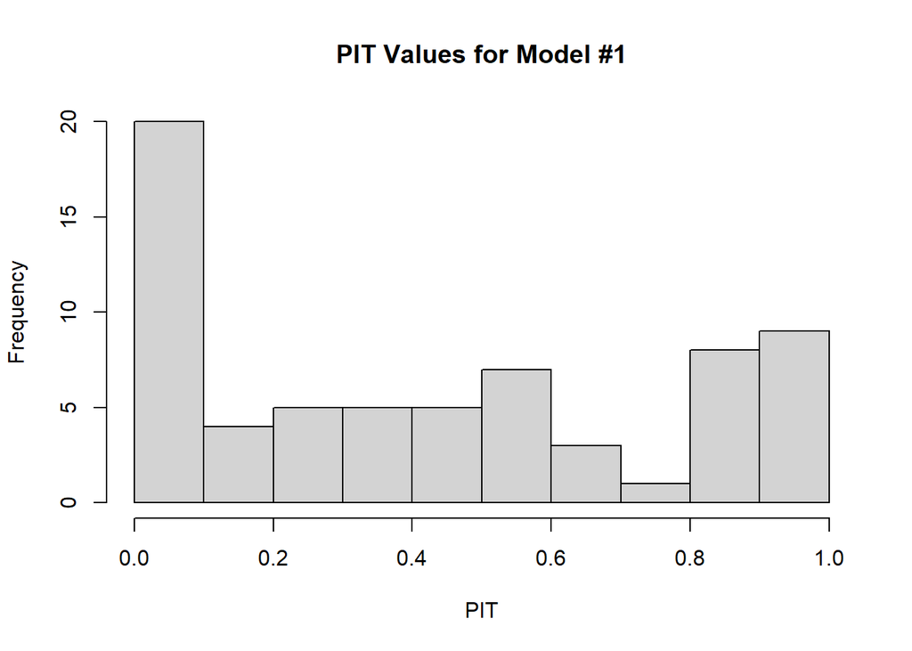

```r
# Histogram of the PIT Values for the Model:
hist(res.penn1$cpo$pit, xlab = "PIT", main = "PIT Values for Model #1")
```

#### Model #2: Hierarchical Random Effect (iid) - (intercept only)

```r
summary(res.penn2)
```

```
##
## Call:
##    c("inla(formula = formula.penn2, family = \"poisson\", data =
##    pennLC.sf, ", " E = E.penn, control.compute = list(cpo = TRUE),
##    control.predictor = list(compute = TRUE))" )
## Time used:
##     Pre = 0.362, Running = 0.415, Post = 0.381, Total = 1.16
## Fixed effects:
##               mean    sd 0.025quant 0.5quant 0.975quant   mode kld
## (Intercept) -0.045 0.018     -0.082   -0.045     -0.011 -0.044   0
##
## Random effects:
##   Name     Model
##     re_v IID model
##
## Model hyperparameters:
##                      mean    sd 0.025quant 0.5quant 0.975quant   mode
## Precision for re_v 135.71 57.40      60.59   124.00     279.66 105.31
##
## Expected number of effective parameters(stdev): 27.44(4.89)
## Number of equivalent replicates : 2.44
##
## Marginal log-Likelihood:  -273.25
## CPO and PIT are computed
##
## Posterior marginals for the linear predictor and
##  the fitted values are computed
```

```r
# sum(log(CPO)) for the Model:
sum(log(res.penn2$cpo$cpo))
```

```
## [1] -267.3744
```

```r
# Mean and 95% Credible Intervals of the Estimated Parameters, and sum(log(CPO)) for the Model Table:
res.penn2.ci.table <- matrix(c(-0.045, -0.082, -0.011, -267.3744, 135.71, 60.59,
                               279.66, -267.3744), nrow = 2, ncol = 4, byrow = TRUE)

colnames(res.penn2.ci.table) <- c("Mean", "Lower Bound", "Upper Bound",
                             "sum(log(CPO)) for the Model")
rownames(res.penn2.ci.table) <- c("Beta 0", "re_v")
names(dimnames(res.penn2.ci.table)) <-
  list("", "Mean, 95% Credible Intervals, & sum(log(CPO)) for Model #2")

res.penn2.ci.table <- as.table(res.penn2.ci.table)
res.penn2.ci.table
```

```
##         Mean, 95% Credible Intervals, & sum(log(CPO)) for Model #2
##               Mean Lower Bound Upper Bound sum(log(CPO)) for the Model
##   Beta 0   -0.0450     -0.0820     -0.0110                   -267.3744
##   re_v    135.7100     60.5900    279.6600                   -267.3744
```

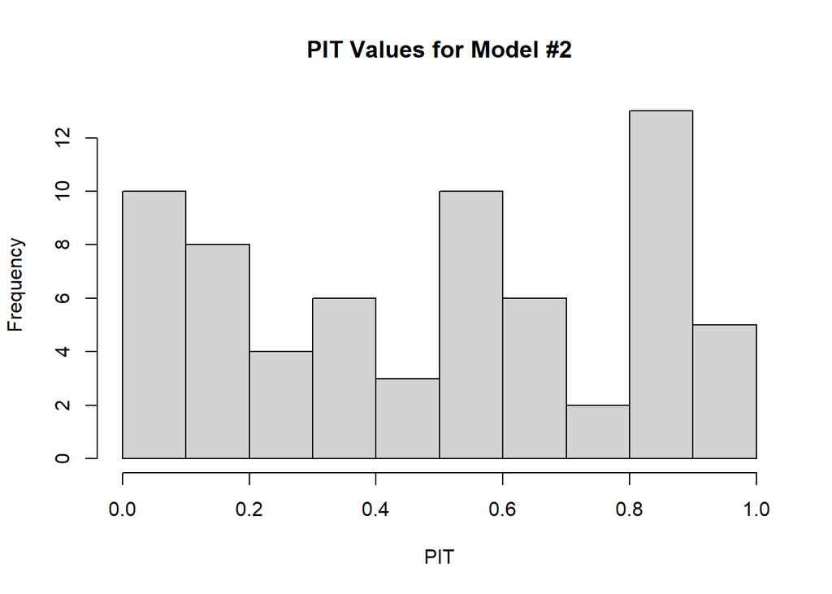

```r
# Histogram of the PIT Values for the Model:
hist(res.penn2$cpo$pit, xlab = "PIT", main = "PIT Values for Model #2")
```

#### Model #3: Hierarchical Random Effect (iid) + Smoking Covariate

```r
summary(res.penn3)
```

```
##
## Call:
##    c("inla(formula = formula.penn3, family = \"poisson\", data =
##    pennLC.sf, ", " E = E.penn, control.compute = list(cpo = TRUE),
##    control.predictor = list(compute = TRUE))" )
## Time used:
##     Pre = 0.372, Running = 0.416, Post = 0.287, Total = 1.08
## Fixed effects:
##               mean    sd 0.025quant 0.5quant 0.975quant   mode kld
## (Intercept) -0.319 0.163     -0.642   -0.318      0.000 -0.317   0
## smoking      1.158 0.680     -0.186    1.158      2.498  1.158   0
##
## Random effects:
##   Name     Model
##     re_v IID model
##
## Model hyperparameters:
##                      mean    sd 0.025quant 0.5quant 0.975quant   mode
## Precision for re_v 150.90 70.55      63.95   135.33     330.68 112.25
##
## Expected number of effective parameters(stdev): 26.77(5.08)
## Number of equivalent replicates : 2.50
##
## Marginal log-Likelihood:  -275.61
## CPO and PIT are computed
##
## Posterior marginals for the linear predictor and
##  the fitted values are computed
```

```r
# sum(log(CPO)) for the Model:
sum(log(res.penn3$cpo$cpo))
```

```
## [1] -267.0355
```

```r
# Mean and 95% Credible Intervals of the Estimated Parameters, and sum(log(CPO)) for the Model Table:
res.penn3.ci.table <- matrix(c(-0.319, -0.642, 0.000, -267.0355, 1.158, -0.186,
                               2.498, -267.0355, 150.90, 63.95, 330.68, -267.0355),
                             nrow = 3, ncol = 4, byrow = TRUE)

colnames(res.penn3.ci.table) <- c("Mean", "Lower Bound", "Upper Bound",
                             "sum(log(CPO)) for the Model")
rownames(res.penn3.ci.table) <- c("Beta 0", "Beta 1", "re_v")
names(dimnames(res.penn3.ci.table)) <-
  list("", "Mean, 95% Credible Intervals, & sum(log(CPO)) for Model #3")

res.penn3.ci.table <- as.table(res.penn3.ci.table)
res.penn3.ci.table
```

```
##         Mean, 95% Credible Intervals, & sum(log(CPO)) for Model #3
##               Mean Lower Bound Upper Bound sum(log(CPO)) for the Model
##   Beta 0   -0.3190     -0.6420      0.0000                   -267.0355
##   Beta 1    1.1580     -0.1860      2.4980                   -267.0355
##   re_v    150.9000     63.9500    330.6800                   -267.0355
```

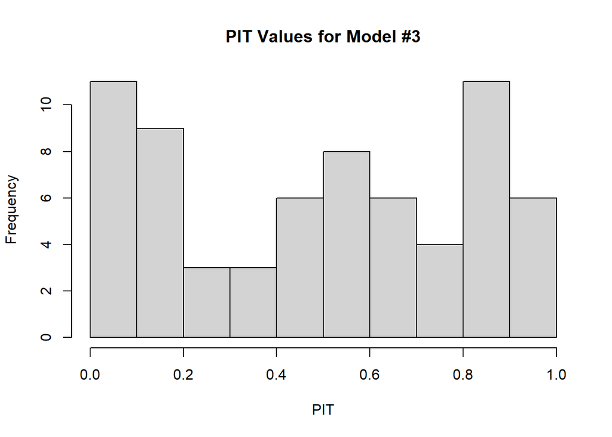

```r
# Histogram of the PIT Values for the Model:
hist(res.penn3$cpo$pit, xlab = "PIT", main = "PIT Values for Model #3")
```

#### Model #4: Spatial + iid Random Effect

```r
summary(res.penn4)
```

```
##
## Call:
##    c("inla(formula = formula.penn4, family = \"poisson\", data =
##    pennLC.sf, ", " E = E.penn, control.compute = list(cpo = TRUE),
##    control.predictor = list(compute = TRUE))" )
## Time used:
##     Pre = 0.43, Running = 1.4, Post = 0.37, Total = 2.2
## Fixed effects:
##               mean    sd 0.025quant 0.5quant 0.975quant   mode kld
## (Intercept) -0.048 0.015     -0.077   -0.048      -0.02 -0.048   0
##
## Random effects:
##   Name     Model
##     re_u Besags ICAR model
##    re_v IID model
##
## Model hyperparameters:
##                        mean       sd 0.025quant 0.5quant 0.975quant    mode
## Precision for re_u    77.38    37.86      28.18    69.42     172.67   56.06
## Precision for re_v 17779.27 17878.85    1108.96 12433.51   65491.05 2969.32
##
## Expected number of effective parameters(stdev): 19.55(4.38)
## Number of equivalent replicates : 3.43
##
## Marginal log-Likelihood:  -318.38
## CPO and PIT are computed
##
## Posterior marginals for the linear predictor and
##  the fitted values are computed
```

```r
# sum(log(CPO)) for the Model:
sum(log(res.penn4$cpo$cpo))
```

```
## [1] -263.0361
```

```r
# Mean and 95% Credible Intervals of the Estimated Parameters, and sum(log(CPO)) for the Model Table:
res.penn4.ci.table <- matrix(c(-0.048, -0.077, -0.02, -263.0361, 77.38, 28.18,
                               172.67, -263.0361, 17779.27, 1108.96, 65491.05, -263.0361),
                             nrow = 3, ncol = 4, byrow = TRUE)

colnames(res.penn4.ci.table) <- c("Mean", "Lower Bound", "Upper Bound",
                             "sum(log(CPO)) for the Model")
rownames(res.penn4.ci.table) <- c("Beta 0", "re_u", "re_v")
names(dimnames(res.penn4.ci.table)) <-
  list("", "Mean, 95% Credible Intervals, & sum(log(CPO)) for Model #4")

res.penn4.ci.table <- as.table(res.penn4.ci.table)
res.penn4.ci.table
```

```
##         Mean, 95% Credible Intervals, & sum(log(CPO)) for Model #4
##                Mean Lower Bound Upper Bound sum(log(CPO)) for the Model
##   Beta 0    -0.0480     -0.0770     -0.0200                   -263.0361
##   re_u      77.3800     28.1800    172.6700                   -263.0361
##   re_v   17779.2700   1108.9600  65491.0500                   -263.0361
```

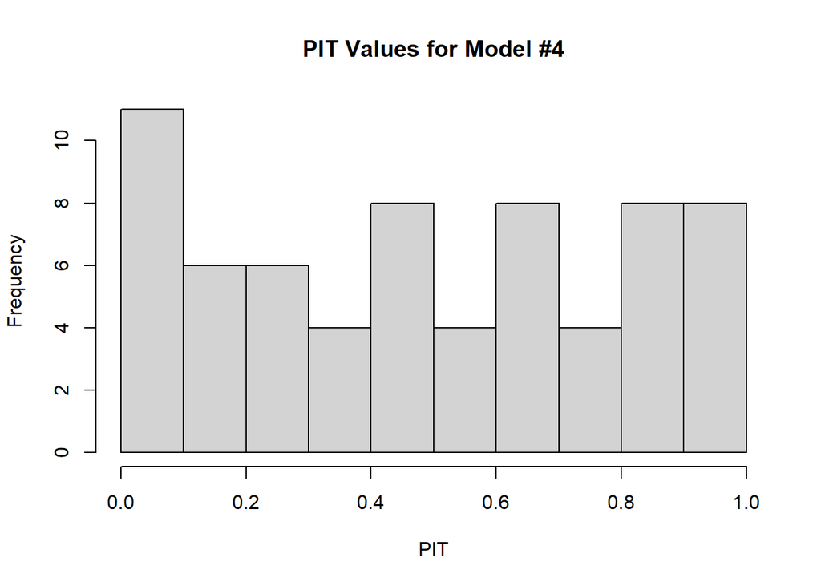

```r
# Histogram of the PIT Values for the Model:
hist(res.penn4$cpo$pit, xlab = "PIT", main = "PIT Values for Model #4")
```

#### Model #5: Spatial + iid Random Effect + Smoking Covariate

```r
summary(res.penn5)
```

```
##
## Call:
##    c("inla(formula = formula.penn5, family = \"poisson\", data =
##    pennLC.sf, ", " E = E.penn, control.compute = list(cpo = TRUE),
##    control.predictor = list(compute = TRUE))" )
## Time used:
##     Pre = 0.418, Running = 1.49, Post = 0.342, Total = 2.25
## Fixed effects:
##               mean    sd 0.025quant 0.5quant 0.975quant   mode kld
## (Intercept) -0.323 0.150     -0.621   -0.323     -0.028 -0.323   0
## smoking      1.156 0.624     -0.080    1.157      2.384  1.160   0
##
## Random effects:
##   Name     Model
##     re_u Besags ICAR model
##    re_v IID model
##
## Model hyperparameters:
##                        mean       sd 0.025quant 0.5quant 0.975quant    mode
## Precision for re_u    92.67    50.19      31.00    81.16     221.44   62.96
## Precision for re_v 18097.70 18216.37    1165.24 12665.38   66267.31 3144.29
##
## Expected number of effective parameters(stdev): 18.66(4.43)
## Number of equivalent replicates : 3.59
##
## Marginal log-Likelihood:  -320.54
## CPO and PIT are computed
##
## Posterior marginals for the linear predictor and
##  the fitted values are computed
```

```r
# sum(log(CPO)) for the Model:
sum(log(res.penn5$cpo$cpo))
```

```
## [1] -261.9656
```

```r
# Mean and 95% Credible Intervals of the Estimated Parameters, and sum(log(CPO)) for the Model Table:
res.penn5.ci.table <- matrix(c(-0.323, -0.621, -0.028, -261.9656, 1.156, -0.080,
                               2.384, -261.9656, 92.67, 31.00, 221.44, -261.9656,
                               18097.70, 1165.24, 66267.31, -261.9656),
                             nrow = 4, ncol = 4, byrow = TRUE)

colnames(res.penn5.ci.table) <- c("Mean", "Lower Bound", "Upper Bound",
                             "sum(log(CPO)) for the Model")
rownames(res.penn5.ci.table) <- c("Beta 0", "Beta 1", "re_u", "re_v")
names(dimnames(res.penn5.ci.table)) <-
  list("", "Mean, 95% Credible Intervals, & sum(log(CPO)) for Model #5")

res.penn5.ci.table <- as.table(res.penn5.ci.table)
res.penn5.ci.table
```

```
##         Mean, 95% Credible Intervals, & sum(log(CPO)) for Model #5
##                Mean Lower Bound Upper Bound sum(log(CPO)) for the Model
##   Beta 0    -0.3230     -0.6210     -0.0280                   -261.9656
##   Beta 1     1.1560     -0.0800      2.3840                   -261.9656
##   re_u      92.6700     31.0000    221.4400                   -261.9656
##   re_v   18097.7000   1165.2400  66267.3100                   -261.9656
```

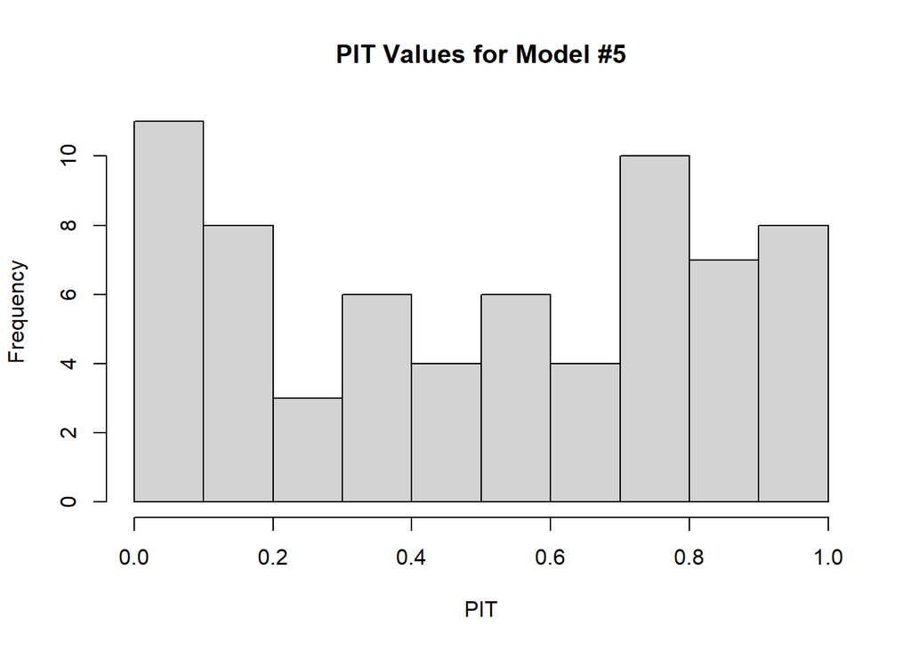

```r
# Histogram of the PIT Values for the Model:
hist(res.penn5$cpo$pit, xlab = "PIT", main = "PIT Values for Model #5")
```

The model that has the best predictive performance as measured by sum log(CPO) is Model #5: Spatial + iid Random Effect + Smoking Covariate (the full model) because it has the highest sum log(CPO), -261.9656, which means the model makes better predictions of the observations (more accurate predictions) when compared to the other models. Hence, the model is a better fit for predictions when using the observations since the other models possibly have more outliers.

# Question 3:

#### INLA Model for 1st Fold:

```r
load("~/Hwk4Data_STA465.RData")

# To view the data to put into 4 folds
tm_basemap(leaflet::providers$Stamen) +
  tm_shape(gambia.sf) + tm_dots(col = c("x", "y")) +
  tm_facets(ncol = 1)
```

[interactive chart not shown]

```r
## Prediction data
dp <- d %>% filter(x < 400000 & y < 1470000)
dim(dp)
```

```
## [1] 13  8
```

```r
# Estimation data
dd <- d
for (i in 1:length(dp$x)) {
  dd <- dd %>% filter(x != dp$x[i])
  }
dim(dd)
```

```
## [1] 52  8
```

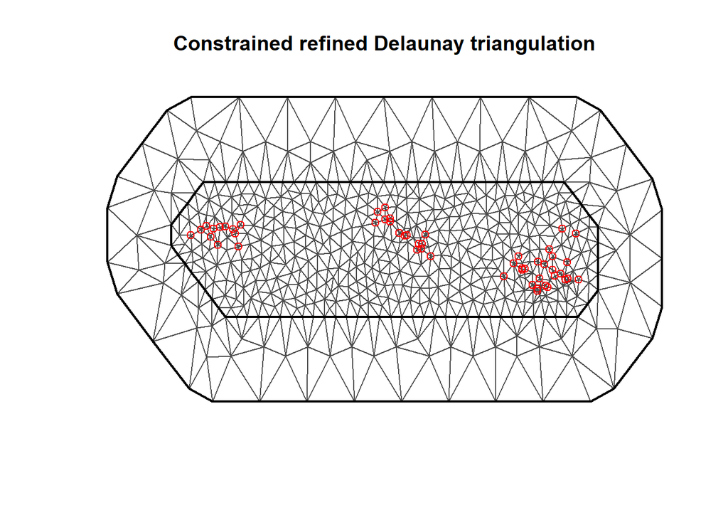

```r
# Mesh construction
coo <- cbind(dd$long, dd$lat)
mesh <- inla.mesh.2d(loc = coo, max.edge = c(0.1, 5), cutoff = 0.01)
plot(mesh)
points(coo, col = "red")
```

```r
# SPDE2 Matérn
spde <- inla.spde2.matern(mesh = mesh, alpha = 2, constr = TRUE)

indexs <- inla.spde.make.index("s", spde$n.spde)
A <- inla.spde.make.A(mesh = mesh, loc = coo)

coop <- cbind("x" = dp$x, "y" = dp$y)
Ap <- inla.spde.make.A(mesh = mesh, loc = coop)

# stack for estimation stk.e
stk.e <- inla.stack(tag = "est", data = list(y = dd$positive, numtrials = dd$total),
                    A = list(1, A), effects = list(data.frame(b0 = 1, altitude = dd$alt), s = indexs))

# stack for prediction stk.p
stk.p <- inla.stack(tag = "pred", data = list(y = NA, numtrials = NA), A = list(1, Ap),
                    effects = list(data.frame(b0 = 1, altitude = dp[, 8]), s = indexs))

# stk.full has stk.e and stk.p
stk.full <- inla.stack(stk.e, stk.p)

formula <- y ~ 0 + b0 + altitude + f(s, model = spde)

res.gambia <- inla(formula, family = "binomial", Ntrials = numtrials,
                   control.family = list(link = "logit"),
                   data = inla.stack.data(stk.full),
                   control.predictor = list(compute = TRUE, link = 1, A = inla.stack.A(stk.full)))

summary(res.gambia)
```

```
##
## Call:
##    c("inla(formula = formula, family = \"binomial\", data =
##    inla.stack.data(stk.full), ", " Ntrials = numtrials, control.predictor
##    = list(compute = TRUE, ", " link = 1, A = inla.stack.A(stk.full)),
##    control.family = list(link = \"logit\"))" )
## Time used:
##     Pre = 0.804, Running = 2.23, Post = 0.44, Total = 3.47
## Fixed effects:
##            mean    sd 0.025quant 0.5quant 0.975quant   mode kld
## b0       -0.575 0.627     -1.693   -0.621      0.811 -0.695   0
## altitude  0.006 0.013     -0.019    0.005      0.032  0.005   0
##
## Random effects:
##   Name     Model
##     s SPDE2 model
##
## Model hyperparameters:
##               mean    sd 0.025quant 0.5quant 0.975quant  mode
## Theta1 for s -3.75 0.262      -4.25    -3.76      -3.22 -3.80
## Theta2 for s  2.29 0.405       1.45     2.30       3.04  2.36
##
## Expected number of effective parameters(stdev): 32.80(3.23)
## Number of equivalent replicates : 1.58
##
## Marginal log-Likelihood:  -172.09
## Posterior marginals for the linear predictor and
##  the fitted values are computed
```

```r
# Computing (1/N)*sum((y_i - yhat_i)^2), where yhat_i is the out-of-sample predicted value of y_i given N_i
index <- inla.stack.index(stack = stk.full, tag = "pred")$data
gambia.mean.prev <- res.gambia$summary.fitted.values[index, "mean"]
N_i <- dp$total
gambia.y.hat <- gambia.mean.prev*N_i
N <- sum(dp$total)
(1/N)*(sum((dp$positive - gambia.y.hat)^2))
```

```
## [1] 0.9864937
```

#### INLA Model for 2nd Fold:

```r
## Prediction data
dp2 <- d %>% filter(x < 400000 & y > 1470000)
dim(dp2)
```

```
## [1] 12  8
```

```r
# Estimation data
dd2 <- d
for (i in 1:length(dp2$x)) {
  dd2 <- dd2 %>% filter(x != dp2$x[i])
  }
dim(dd2)
```

```
## [1] 53  8
```

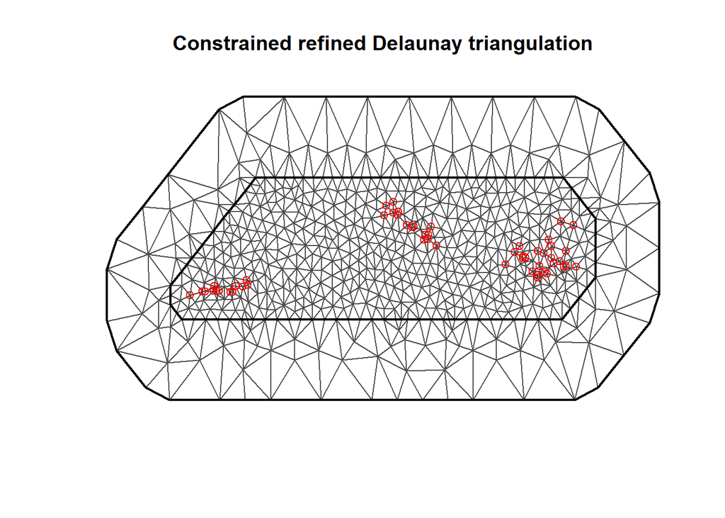

```r
# Mesh construction
coo2 <- cbind(dd2$long, dd2$lat)
mesh2 <- inla.mesh.2d(loc = coo2, max.edge = c(0.1, 5), cutoff = 0.01)
plot(mesh2)
points(coo2, col = "red")
```

```r
# SPDE2 Matérn
spde2 <- inla.spde2.matern(mesh = mesh2, alpha = 2, constr = TRUE)

indexs2 <- inla.spde.make.index("s", spde2$n.spde)
A2 <- inla.spde.make.A(mesh = mesh2, loc = coo2)

coop2 <- cbind("x" = dp2$x, "y" = dp2$y)
Ap2 <- inla.spde.make.A(mesh = mesh2, loc = coop2)

# stack for estimation stk.e
stk.e.2 <- inla.stack(tag = "est", data = list(y = dd2$positive, numtrials = dd2$total),
                      A = list(1, A2), effects = list(data.frame(b0 = 1, altitude = dd2$alt), s = indexs2))

# stack for prediction stk.p
stk.p.2 <- inla.stack(tag = "pred", data = list(y = NA, numtrials = NA), A = list(1, Ap2),
                      effects = list(data.frame(b0 = 1, altitude = dp2[, 8]), s = indexs2))

# stk.full has stk.e and stk.p
stk.full2 <- inla.stack(stk.e.2, stk.p.2)

formula2 <- y ~ 0 + b0 + altitude + f(s, model = spde2)

res.gambia2 <- inla(formula2, family = "binomial", Ntrials = numtrials,
                    control.family = list(link = "logit"),
                    data = inla.stack.data(stk.full2),
                    control.predictor = list(compute = TRUE, link = 1, A = inla.stack.A(stk.full2)))

summary(res.gambia2)
```

```
##
## Call:
##    c("inla(formula = formula2, family = \"binomial\", data =
##    inla.stack.data(stk.full2), ", " Ntrials = numtrials, control.predictor
##    = list(compute = TRUE, ", " link = 1, A = inla.stack.A(stk.full2)),
##    control.family = list(link = \"logit\"))" )
## Time used:
##     Pre = 0.785, Running = 3, Post = 0.422, Total = 4.2
## Fixed effects:
##            mean    sd 0.025quant 0.5quant 0.975quant   mode kld
## b0        0.152 0.599     -0.882    0.099      1.501  0.013   0
## altitude -0.018 0.013     -0.043   -0.018      0.008 -0.018   0
##
## Random effects:
##   Name     Model
##     s SPDE2 model
##
## Model hyperparameters:
##               mean    sd 0.025quant 0.5quant 0.975quant  mode
## Theta1 for s -3.82 0.315      -4.45    -3.81      -3.21 -3.80
## Theta2 for s  2.44 0.432       1.60     2.44       3.30  2.43
##
## Expected number of effective parameters(stdev): 32.60(3.63)
## Number of equivalent replicates : 1.63
##
## Marginal log-Likelihood:  -176.67
## Posterior marginals for the linear predictor and
##  the fitted values are computed
```

```r
# Computing (1/N)*sum((y_i - yhat_i)^2), where yhat_i is the out-of-sample predicted value of y_i given N_i
index2 <- inla.stack.index(stack = stk.full2, tag = "pred")$data
gambia.mean.prev2 <- res.gambia2$summary.fitted.values[index2, "mean"]
N_i.2 <- dp2$total
gambia.y.hat2 <- gambia.mean.prev2*N_i.2
N.2 <- sum(dp2$total)
(1/N.2)*(sum((dp2$positive - gambia.y.hat2)^2))
```

```
## [1] 4.534567
```

#### INLA Model for 3rd Fold:

```r
## Prediction data
dp3 <- d %>% filter(x > 400000 & x < 550000)
dim(dp3)
```

```
## [1] 15  8
```

```r
# Estimation data
dd3 <- d
for (i in 1:length(dp3$x)) {
  dd3 <- dd3 %>% filter(x != dp3$x[i])
  }
dim(dd3)
```

```
## [1] 50  8
```

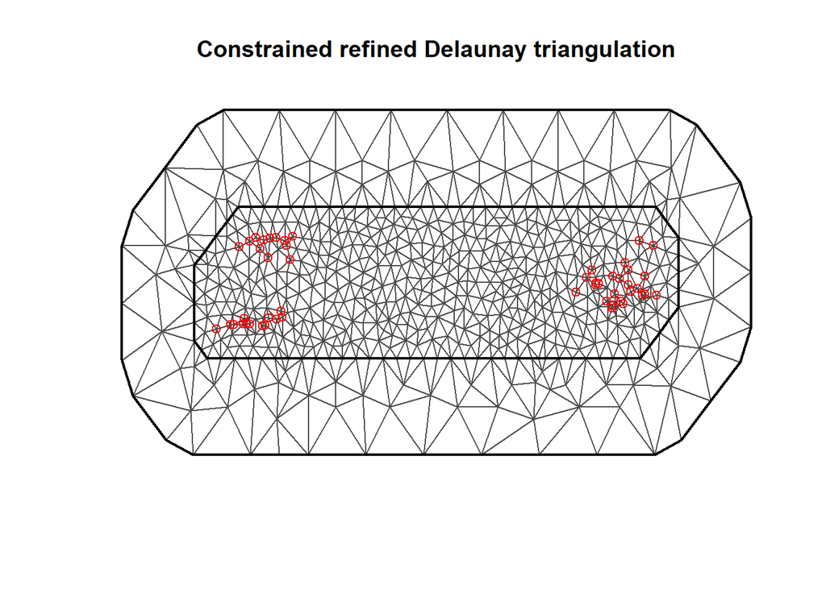

```r
# Mesh construction
coo3 <- cbind(dd3$long, dd3$lat)
mesh3 <- inla.mesh.2d(loc = coo3, max.edge = c(0.1, 5), cutoff = 0.01)
plot(mesh3)
points(coo3, col = "red")
```

```r
# SPDE2 Matérn
spde3 <- inla.spde2.matern(mesh = mesh3, alpha = 2, constr = TRUE)

indexs3 <- inla.spde.make.index("s", spde3$n.spde)
A3 <- inla.spde.make.A(mesh = mesh3, loc = coo3)

coop3 <- cbind("x" = dp3$x, "y" = dp3$y)
Ap3 <- inla.spde.make.A(mesh = mesh3, loc = coop3)

# stack for estimation stk.e
stk.e.3 <- inla.stack(tag = "est", data = list(y = dd3$positive, numtrials = dd3$total),
                      A = list(1, A3), effects = list(data.frame(b0 = 1, altitude = dd3$alt), s = indexs3))

# stack for prediction stk.p
stk.p.3 <- inla.stack(tag = "pred", data = list(y = NA, numtrials = NA), A = list(1, Ap3),
                      effects = list(data.frame(b0 = 1, altitude = dp3[, 8]), s = indexs3))

# stk.full has stk.e and stk.p
stk.full3 <- inla.stack(stk.e.3, stk.p.3)

formula3 <- y ~ 0 + b0 + altitude + f(s, model = spde3)

res.gambia3 <- inla(formula3, family = "binomial", Ntrials = numtrials,
                    control.family = list(link = "logit"),
                    data = inla.stack.data(stk.full3),
                    control.predictor = list(compute = TRUE, link = 1, A = inla.stack.A(stk.full3)))

summary(res.gambia3)
```

```
##
## Call:
##    c("inla(formula = formula3, family = \"binomial\", data =
##    inla.stack.data(stk.full3), ", " Ntrials = numtrials, control.predictor
##    = list(compute = TRUE, ", " link = 1, A = inla.stack.A(stk.full3)),
##    control.family = list(link = \"logit\"))" )
## Time used:
##     Pre = 0.882, Running = 3.65, Post = 0.471, Total = 5
## Fixed effects:
##            mean    sd 0.025quant 0.5quant 0.975quant   mode kld
## b0       -0.069 0.627     -1.103   -0.140      1.398 -0.246   0
## altitude -0.005 0.016     -0.034   -0.005      0.027 -0.006   0
##
## Random effects:
##   Name     Model
##     s SPDE2 model
##
## Model hyperparameters:
##               mean    sd 0.025quant 0.5quant 0.975quant  mode
## Theta1 for s -4.25 0.331      -4.86    -4.27      -3.56 -4.33
## Theta2 for s  2.96 0.396       2.14     2.98       3.69  3.06
##
## Expected number of effective parameters(stdev): 35.93(3.19)
## Number of equivalent replicates : 1.39
##
## Marginal log-Likelihood:  -174.71
## Posterior marginals for the linear predictor and
##  the fitted values are computed
```

```r
# Computing (1/N)*sum((y_i - yhat_i)^2), where yhat_i is the out-of-sample predicted value of y_i given N_i
index3 <- inla.stack.index(stack = stk.full3, tag = "pred")$data
gambia.mean.prev3 <- res.gambia3$summary.fitted.values[index3, "mean"]
N_i.3 <- dp3$total
gambia.y.hat3 <- gambia.mean.prev3*N_i.3
N.3 <- sum(dp3$total)
(1/N.3)*(sum((dp3$positive - gambia.y.hat3)^2))
```

```
## [1] 2.873532
```

#### INLA Model for 4th Fold:

```r
## Prediction data
dp4 <- d %>% filter(x > 550000)
dim(dp4)
```

```
## [1] 25  8
```

```r
# Estimation data
dd4 <- d
for (i in 1:length(dp4$x)) {
  dd4 <- dd4 %>% filter(x != dp4$x[i])
  }
dim(dd4)
```

```
## [1] 40  8
```

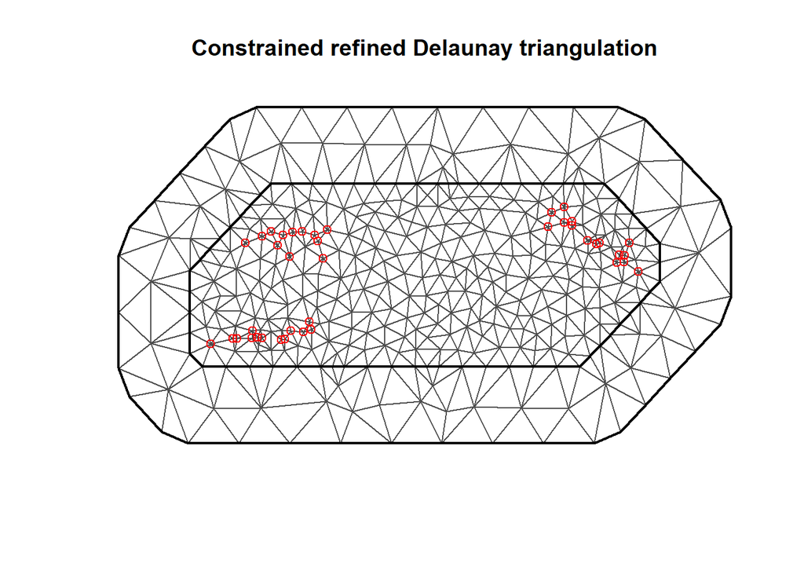

```r
# Mesh construction
coo4 <- cbind(dd4$long, dd4$lat)
mesh4 <- inla.mesh.2d(loc = coo4, max.edge = c(0.1, 5), cutoff = 0.01)
plot(mesh4)
points(coo4, col = "red")
```

```r
# SPDE2 Matérn
spde4 <- inla.spde2.matern(mesh = mesh4, alpha = 2, constr = TRUE)

indexs4 <- inla.spde.make.index("s", spde4$n.spde)
A4 <- inla.spde.make.A(mesh = mesh4, loc = coo4)

coop4 <- cbind("x" = dp4$x, "y" = dp4$y)
Ap4 <- inla.spde.make.A(mesh = mesh4, loc = coop4)

# stack for estimation stk.e
stk.e.4 <- inla.stack(tag = "est", data = list(y = dd4$positive, numtrials = dd4$total),
                      A = list(1, A4), effects = list(data.frame(b0 = 1, altitude = dd4$alt), s = indexs4))

# stack for prediction stk.p
stk.p.4 <- inla.stack(tag = "pred", data = list(y = NA, numtrials = NA), A = list(1, Ap4),
                      effects = list(data.frame(b0 = 1, altitude = dp4[, 8]), s = indexs4))

# stk.full has stk.e and stk.p
stk.full4 <- inla.stack(stk.e.4, stk.p.4)

formula4 <- y ~ 0 + b0 + altitude + f(s, model = spde4)

res.gambia4 <- inla(formula4, family = "binomial", Ntrials = numtrials,
                    control.family = list(link = "logit"),
                    data = inla.stack.data(stk.full4),
                    control.predictor = list(compute = TRUE, link = 1, A = inla.stack.A(stk.full4)))

summary(res.gambia4)
```

```
##
## Call:
##    c("inla(formula = formula4, family = \"binomial\", data =
##    inla.stack.data(stk.full4), ", " Ntrials = numtrials, control.predictor
##    = list(compute = TRUE, ", " link = 1, A = inla.stack.A(stk.full4)),
##    control.family = list(link = \"logit\"))" )
## Time used:
##     Pre = 0.81, Running = 2.5, Post = 0.418, Total = 3.73
## Fixed effects:
##            mean    sd 0.025quant 0.5quant 0.975quant   mode kld
## b0       -1.109 0.453     -1.971   -1.121     -0.175 -1.142   0
## altitude  0.001 0.018     -0.034    0.001      0.035  0.001   0
##
## Random effects:
##   Name     Model
##     s SPDE2 model
##
## Model hyperparameters:
##               mean    sd 0.025quant 0.5quant 0.975quant  mode
## Theta1 for s -4.90 0.445      -5.79    -4.89      -4.05 -4.86
## Theta2 for s  3.66 0.379       2.93     3.65       4.42  3.63
##
## Expected number of effective parameters(stdev): 30.00(2.34)
## Number of equivalent replicates : 1.33
##
## Marginal log-Likelihood:  -137.22
## Posterior marginals for the linear predictor and
##  the fitted values are computed
```

```r
# Computing (1/N)*sum((y_i - yhat_i)^2), where yhat_i is the out-of-sample predicted value of y_i given N_i
index4 <- inla.stack.index(stack = stk.full4, tag = "pred")$data
gambia.mean.prev4 <- res.gambia4$summary.fitted.values[index4, "mean"]
N_i.4 <- dp4$total
gambia.y.hat4 <- gambia.mean.prev4*N_i.4
N.4 <- sum(dp4$total)
(1/N.4)*(sum((dp4$positive - gambia.y.hat4)^2))
```

```
## [1] 2.589971
```

#### Map that shows how the Data are Partitioned into the 4 Folds:

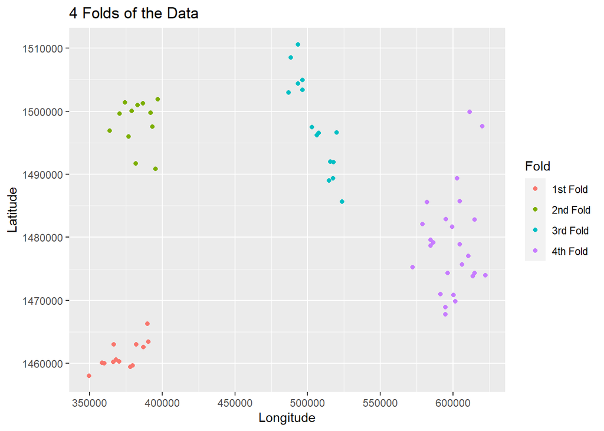

```r
# Map to show the 4 Folds of the Data
colors <- c("1st Fold" = "red", "2nd Fold" = "blue", "3rd Fold" = "orange",
            "4th Fold" = "purple")

ggplot() +
  geom_point(data = tibble(long = coop[, 1], lat = coop[, 2], gambia.y.hat),
             aes(long, lat, col = "1st Fold")) +
  geom_point(data = tibble(long = coop2[, 1], lat = coop2[, 2], gambia.y.hat2),
             aes(long, lat, col = "2nd Fold")) +
  geom_point(data = tibble(long = coop3[, 1], lat = coop3[, 2], gambia.y.hat3),
             aes(long, lat, col = "3rd Fold")) +
  geom_point(data = tibble(long = coop4[, 1], lat = coop4[, 2], gambia.y.hat4),
             aes(long, lat, col = "4th Fold")) +
  xlab("Longitude") + ylab("Latitude") + ggtitle("4 Folds of the Data") +
  labs(color = "Fold")
```

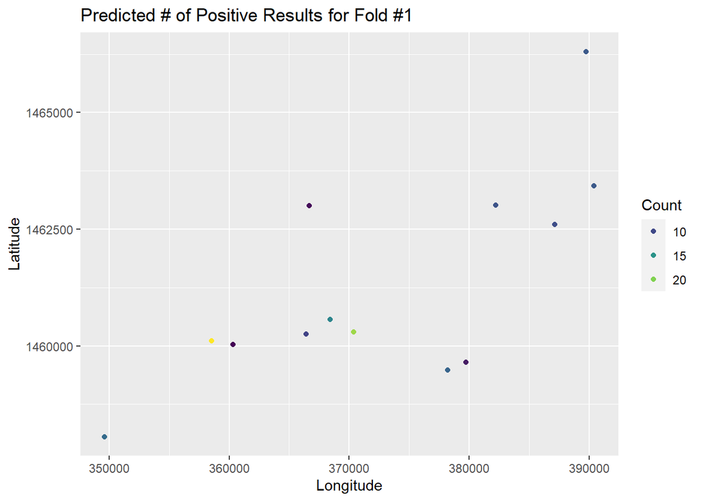

```r
# Map of the corresponding "y.hat" (number of positive results) for each of the folds:
# 1st Fold:
ggplot(data = tibble(long = coop[, 1], lat = coop[, 2], gambia.y.hat), aes(long, lat)) +
  geom_point(aes(col = gambia.y.hat)) +
  xlab("Longitude") + ylab("Latitude") +
  ggtitle("Predicted # of Positive Results for Fold #1") +
  guides(color = guide_legend("Count")) +
  scale_color_viridis_c()
```

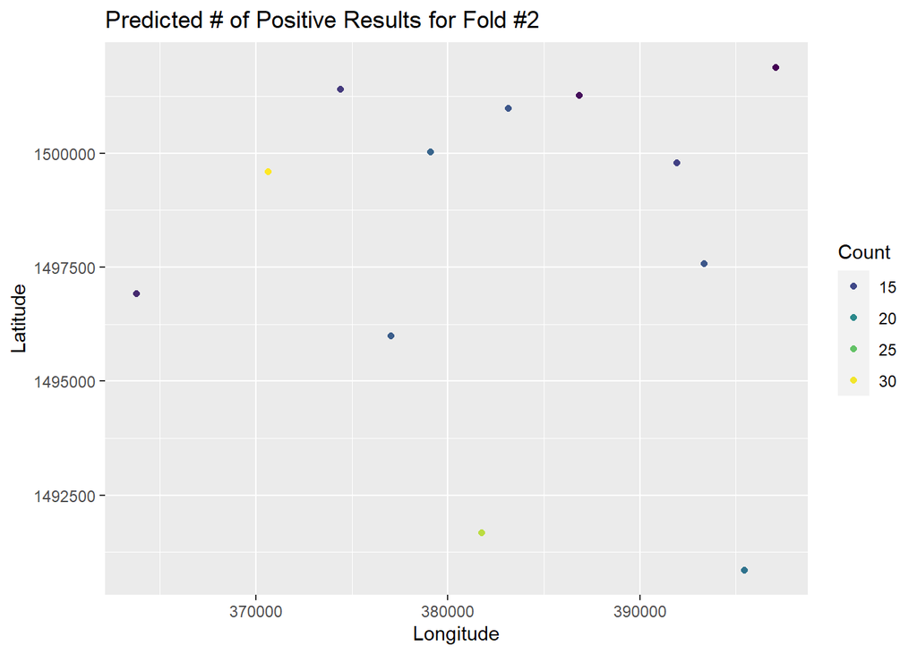

```r
# 2nd Fold:
ggplot(data = tibble(long = coop2[, 1], lat = coop2[, 2], gambia.y.hat2), aes(long, lat)) +
  geom_point(aes(col = gambia.y.hat2)) +
  xlab("Longitude") + ylab("Latitude") +
  ggtitle("Predicted # of Positive Results for Fold #2") +
  guides(color = guide_legend("Count")) +
  scale_color_viridis_c()
```

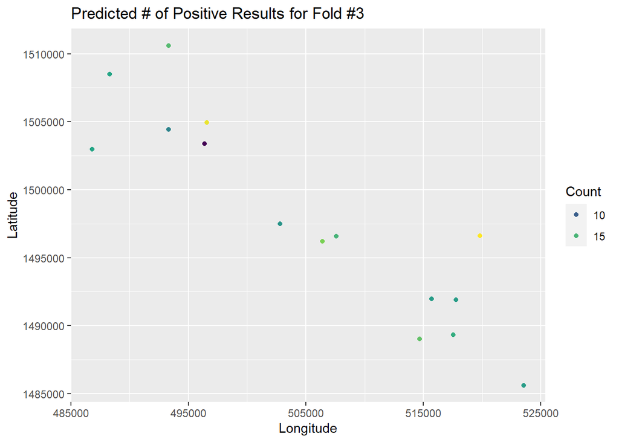

```r
# 3rd Fold:
ggplot(data = tibble(long = coop3[, 1], lat = coop3[, 2], gambia.y.hat3), aes(long, lat)) +
  geom_point(aes(col = gambia.y.hat3)) +
  xlab("Longitude") + ylab("Latitude") +
  ggtitle("Predicted # of Positive Results for Fold #3") +
  guides(color = guide_legend("Count")) +
  scale_color_viridis_c()
```

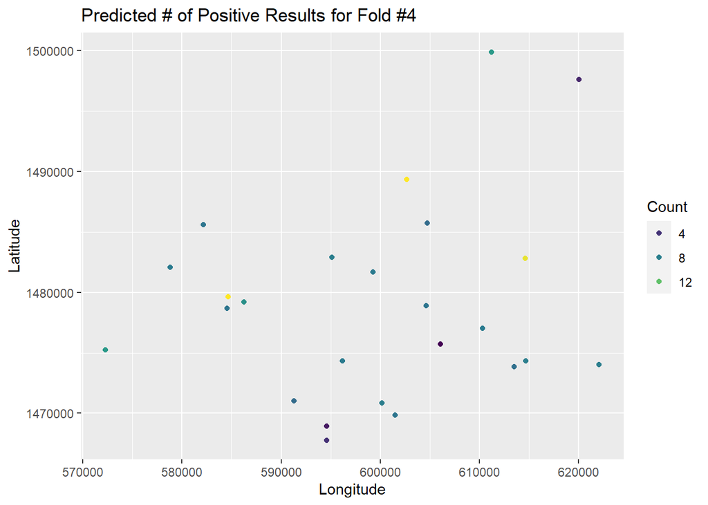

```r
# 4th Fold:
ggplot(data = tibble(long = coop4[, 1], lat = coop4[, 2], gambia.y.hat4), aes(long, lat)) +
  geom_point(aes(col = gambia.y.hat4)) +
  xlab("Longitude") + ylab("Latitude") +
  ggtitle("Predicted # of Positive Results for Fold #4") +
  guides(color = guide_legend("Count")) +
  scale_color_viridis_c()
```